# 01_match_animations

## 01_match_animations

#### Question

1. Match the animations to the equations.

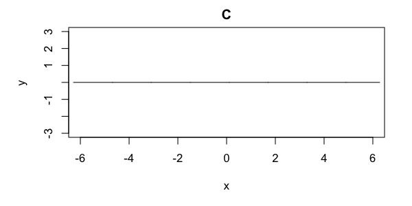

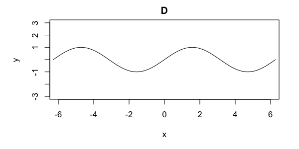

   Match each equation to its animation. In the animations, $t$ goes from 0 to $2\pi$.
   - $y=\sin(x)\cdot \cos(t)~\to$
   - $y=\frac{\sin(x-t)+\sin(x+t)}{2}~\to$
   - $y=\sin(x)+\cos(t)~\to$
   - $y=\sin(x)\cos(t)+\cos(x)\sin(t)~\to$
   - $y=\sin(x\cdot t)~\to$
   - $y=\sin(x+t)~\to$

#### Question

2. Match the animations to the equations.

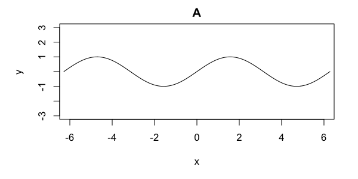

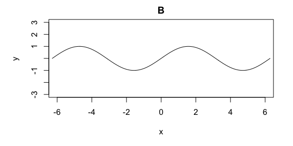

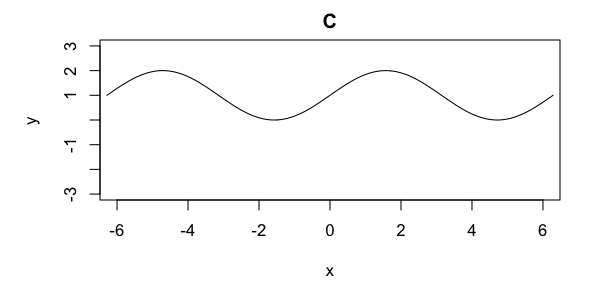

   Match each equation to its animation. In the animations, $t$ goes from 0 to $2\pi$.
   - $y=\sin(x)\cdot \cos(t)~\to$
   - $y=\sin(x)+\cos(t)~\to$
   - $y=\frac{\sin(x-t)+\sin(x+t)}{2}~\to$
   - $y=\sin(x+t)~\to$
   - $y=\sin(x\cdot t)~\to$
   - $y=\sin(x)\cos(t)+\cos(x)\sin(t)~\to$

#### Question

3. Match the animations to the equations.

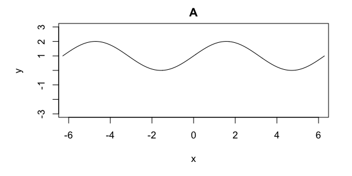

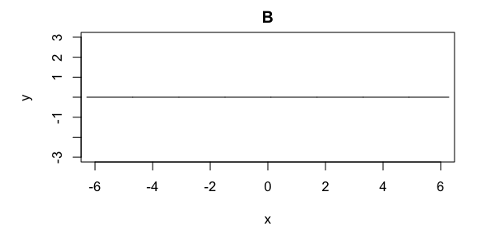

   Match each equation to its animation. In the animations, $t$ goes from 0 to $2\pi$.
   - $y=\sin(x)\cdot \cos(t)~\to$
   - $y=\sin(x)+\cos(t)~\to$
   - $y=\sin(x)\cos(t)+\cos(x)\sin(t)~\to$
   - $y=\sin(x\cdot t)~\to$
   - $y=\sin(x+t)~\to$
   - $y=\frac{\sin(x-t)+\sin(x+t)}{2}~\to$

#### Question

4. Match the animations to the equations.

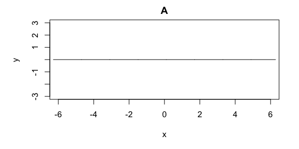

   Match each equation to its animation. In the animations, $t$ goes from 0 to $2\pi$.
   - $y=\frac{\sin(x-t)+\sin(x+t)}{2}~\to$
   - $y=\sin(x\cdot t)~\to$
   - $y=\sin(x+t)~\to$
   - $y=\sin(x)\cos(t)+\cos(x)\sin(t)~\to$
   - $y=\sin(x)\cdot \cos(t)~\to$
   - $y=\sin(x)+\cos(t)~\to$

#### Question

5. Match the animations to the equations.

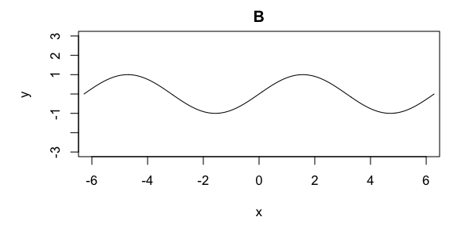

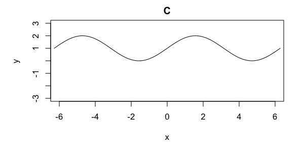

   Match each equation to its animation. In the animations, $t$ goes from 0 to $2\pi$.
   - $y=\sin(x)\cdot \cos(t)~\to$
   - $y=\sin(x+t)~\to$
   - $y=\frac{\sin(x-t)+\sin(x+t)}{2}~\to$
   - $y=\sin(x)\cos(t)+\cos(x)\sin(t)~\to$
   - $y=\sin(x\cdot t)~\to$
   - $y=\sin(x)+\cos(t)~\to$

#### Question

6. Match the animations to the equations.

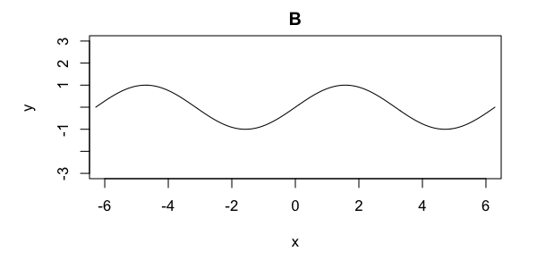

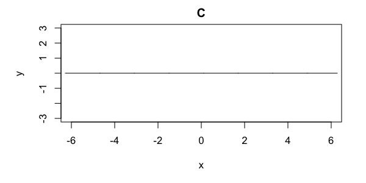

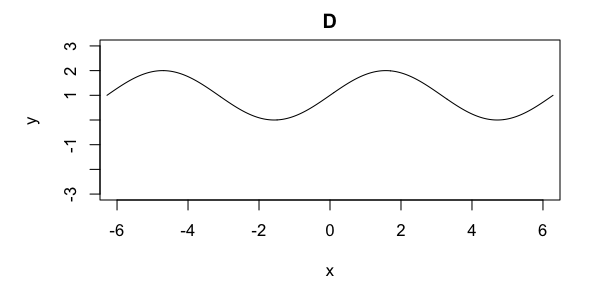

   Match each equation to its animation. In the animations, $t$ goes from 0 to $2\pi$.
   - $y=\frac{\sin(x-t)+\sin(x+t)}{2}~\to$
   - $y=\sin(x\cdot t)~\to$
   - $y=\sin(x)\cdot \cos(t)~\to$
   - $y=\sin(x)\cos(t)+\cos(x)\sin(t)~\to$
   - $y=\sin(x+t)~\to$
   - $y=\sin(x)+\cos(t)~\to$

#### Question

8. Match the animations to the equations.

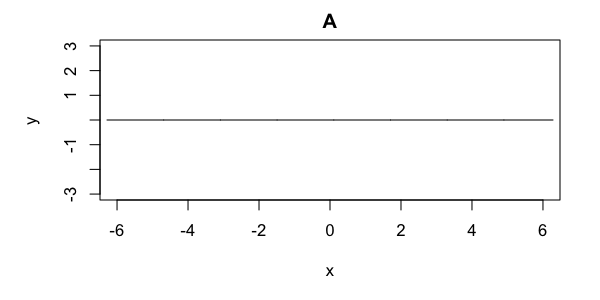

   Match each equation to its animation. In the animations, $t$ goes from 0 to $2\pi$.
   - $y=\sin(x)\cdot \cos(t)~\to$
   - $y=\sin(x\cdot t)~\to$
   - $y=\sin(x+t)~\to$
   - $y=\sin(x)\cos(t)+\cos(x)\sin(t)~\to$
   - $y=\frac{\sin(x-t)+\sin(x+t)}{2}~\to$
   - $y=\sin(x)+\cos(t)~\to$